# Final Project: R Reference

Jessica Bonin

12/16/2021

# R Reference Guide

## Loading Data and Packages

- To load packages, you can install them using **install.packages()**.
- To “turn on” or use a package that you have already installed into r, you can use either **library()** or **require()**.
- The function **here()** lets to tell r where to pull data from your file directory. It starts where your r project is saved, in this case it is in my environmental_data folder.
- To create a data.frame in r, you name your data and tell r where to pull the data from.

```r
# Installing a package
# install.packages("palmerpenguins")

# Turning on a package that was previously installed
library(palmerpenguins)
# OR
require(palmerpenguins)

# Creating a data.frame
penguins <- palmerpenguins::penguins

require(here)
ginkgo <- read.csv(here("data", "ginkgo_data_2021.csv"))
```

## Data Structures

### Vectors

- You can create numeric, character, or boolean vectors by using **c()**.
- You can name the values in a vector or name a whole vector by using **names()**.

```r
# Creating a vector of numbers
numeric_vector <- c(2, 4, 6, 8)

# Creating a vector of characters
character_vector <- c("who", "do", "we", "appreciate")

# Creating a boolean_vector:
boolean_vector <- c(TRUE, TRUE, FALSE)

# Naming numeric_vector
names(numeric_vector) <- c("two", "four", "six", "eight")
```

### Matrices

A matrix is a collection of elements of the same data type. You can name rows or columns in a matrix using **rownames()** and **colnames()**.

```r
# Matrix with numbers 1-9 in 3 rows
my_matrix <- matrix(1:9, byrow = TRUE, nrow = 3)
# You can also use a vector in place of numbers (instead of 1:9). It can be a defined vector or using c().

# Naming rows and columns
rows <- c("row1", "row2", "row3")
columns <- c("col1", "col2", "col3")
rownames(my_matrix) <- rows
colnames(my_matrix) <- columns
```

### Length

Get or set the length of an R object using **length()**.

```r
length(numeric_vector)
```

```
## [1] 4
```

```r
length(boolean_vector)
```

```
## [1] 3
```

```r
length(my_matrix)
```

```
## [1] 9
```

```r
# Find out how many variables are in a data frame
length(ginkgo)
```

```
## [1] 6
```

```r
length(penguins)
```

```
## [1] 8
```

### Data Frames

You can create data frames many different ways (see Loading Data and Packages). This is an example of how to create a data frame from scratch (example from **tutorialspoint.com**).

```r
emp.data <- data.frame(
  emp_id = c (1:5),
  emp_name = c("Rick","Dan","Michelle","Ryan","Gary"),
  salary = c(623.3,515.2,611.0,729.0,843.25),

  start_date = as.Date(c("2012-01-01", "2013-09-23", "2014-11-15", "2014-05-11",
      "2015-03-27")),
  stringsAsFactors = FALSE
)
print(emp.data)
```

```
##   emp_id emp_name salary start_date
## 1      1     Rick 623.30 2012-01-01
## 2      2      Dan 515.20 2013-09-23
## 3      3 Michelle 611.00 2014-11-15
## 4      4     Ryan 729.00 2014-05-11
## 5      5     Gary 843.25 2015-03-27
```

### Data Frame Counts

Use **nrow()** to find out the number of rows/observations in a data frame. Use **ncol()** to find out the number of columns/variables in a data frame. Use **dim()** to find out the dimensions of a data frame.

```r
nrow(ginkgo)
```

```
## [1] 756
```

```r
ncol(ginkgo)
```

```
## [1] 6
```

```r
dim(ginkgo)
```

```
## [1] 756   6
```

## Subsetting

You may want to select elements from a vector, matrix, or data frame. There are a few ways you can do this…

```r
# Using $ to select a column of data
ginkgo$seeds_present
```

```
##   [1] FALSE FALSE FALSE FALSE FALSE FALSE FALSE FALSE FALSE FALSE FALSE FALSE
##  [13] FALSE FALSE FALSE FALSE FALSE FALSE FALSE FALSE FALSE FALSE FALSE FALSE
##  [25] FALSE FALSE FALSE FALSE FALSE FALSE FALSE FALSE FALSE FALSE FALSE FALSE
##  [37] FALSE FALSE FALSE FALSE FALSE FALSE FALSE FALSE FALSE FALSE FALSE FALSE
##  [49] FALSE FALSE FALSE FALSE FALSE FALSE FALSE FALSE FALSE FALSE FALSE FALSE
##  [61] FALSE FALSE FALSE FALSE FALSE FALSE FALSE FALSE FALSE FALSE FALSE FALSE
##  [73] FALSE FALSE FALSE FALSE FALSE FALSE FALSE FALSE FALSE FALSE FALSE FALSE
##  [85] FALSE FALSE FALSE FALSE FALSE FALSE FALSE FALSE FALSE FALSE FALSE FALSE
##  [97] FALSE FALSE FALSE FALSE FALSE FALSE FALSE FALSE FALSE FALSE FALSE FALSE
## [109] FALSE FALSE FALSE FALSE FALSE FALSE FALSE FALSE FALSE FALSE FALSE FALSE
## [121] FALSE FALSE FALSE FALSE FALSE FALSE FALSE FALSE FALSE FALSE FALSE FALSE
## [133] FALSE FALSE FALSE FALSE FALSE FALSE FALSE FALSE FALSE FALSE FALSE FALSE
## [145] FALSE FALSE FALSE FALSE FALSE FALSE FALSE FALSE FALSE FALSE FALSE FALSE
## [157] FALSE FALSE FALSE FALSE FALSE FALSE FALSE FALSE FALSE FALSE FALSE FALSE
## [169] FALSE FALSE FALSE FALSE FALSE FALSE FALSE FALSE FALSE FALSE FALSE FALSE
```

[output cut: 48 more lines]

```r
# Using [] to subset by position:
# Select first row of the ginkgo data
ginkgo[1,]
```

```
##   site_id seeds_present max_width max_depth notch_depth petiole_length
## 1    7719         FALSE        71        40           0             30
```

```r
# Select the element in row 2, column 3
ginkgo[2,3]
```

```
## [1] 64
```

```r
# Select the 3rd column of the ginkgo data
ginkgo[,3]
```

```
##   [1]  71.0  64.0  55.0  62.0  65.0  70.0  63.0  56.0  51.0  57.0  59.0  63.0
##  [13]  70.0  50.0  56.0  46.0  54.0  62.0  56.0  55.0  59.0  60.0  63.0  61.0
##  [25]  58.0  55.0  53.0  81.0  94.0  75.0  82.0  86.0  79.0  93.0  88.0  76.0
##  [37]  71.0  91.0  71.0  82.0  65.0  83.0  73.0 102.0  78.0  88.0  81.0  70.0
##  [49]  80.0  96.0  80.0  82.0  86.0  87.0  89.0  69.0  93.0  98.0  81.0  79.0
##  [61]  82.0  85.0  81.0  59.0  53.0  83.0  80.0  77.0  81.0  76.0  82.0  81.0
##  [73]  77.0  68.0  41.0  70.0  68.0  80.0  89.0  90.0  71.0  64.0  55.0  62.0
##  [85]  65.0  70.0  63.0  56.0  51.0  57.0  59.0  63.0  70.0  50.0  56.0  46.0
##  [97]  54.0  62.0  56.0  55.0  59.0  60.0  63.0  61.0  58.0  55.0  53.0  77.0
## [109]  72.0  57.0  75.0  75.0  75.0  67.0  74.0  71.0  72.0  55.0  77.0  97.0
## [121]  73.0  64.0  69.0  92.0  64.0  68.0  53.0  97.0 100.0  90.0  89.0  59.0
## [133]  97.0  76.0  85.0  90.0  87.0  85.0  80.0  86.0  89.0  84.0  88.0  80.0
## [145] 102.0  94.0  95.0 109.0  84.0  68.0  59.0  74.0  70.0  71.0  69.0  74.0
## [157]  70.0  78.0  87.0  69.0  60.0  72.0  59.0  75.0  81.0  82.0  74.0  72.0
## [169]  79.0  84.0  75.0  72.0  88.0  80.0  90.0  58.0  61.0  95.0  72.0  90.0
```

[output cut: 48 more lines]

```r
# Using subset() function to retrieve all the data for Adelie penguins (in the species column) from the peuguins dataset.
Adelie <- subset(penguins, species == "Adelie")
Gentoo <- subset(penguins, species == "Gentoo")
Chinstrap <- subset(penguins, species == "Chinstrap")
```

## Numerical Data Exploration

- There are functions in r that you can use for data calculations.
- Using **na.rm** will excuse missing data to allow the function to run.

```r
# Summary tells you a summary of the results (compare it to the mean() function).
summary(penguins$body_mass_g)
```

```
##    Min. 1st Qu.  Median    Mean 3rd Qu.    Max.    NA's
##    2700    3550    4050    4202    4750    6300       2
```

```r
mean(penguins$body_mass_g, na.rm = TRUE)
```

```
## [1] 4201.754
```

```r
sd(penguins$body_mass_g, na.rm = TRUE)
```

```
## [1] 801.9545
```

## Graphical Data Exploration

There are many ways to graph data in r. The most common I have used are: scatterplots, histograms, and boxplots.

### Scatterplots

Scatterplots graph data as (x,y) points. They are helpful in evaluating trends in the relationships of the data.

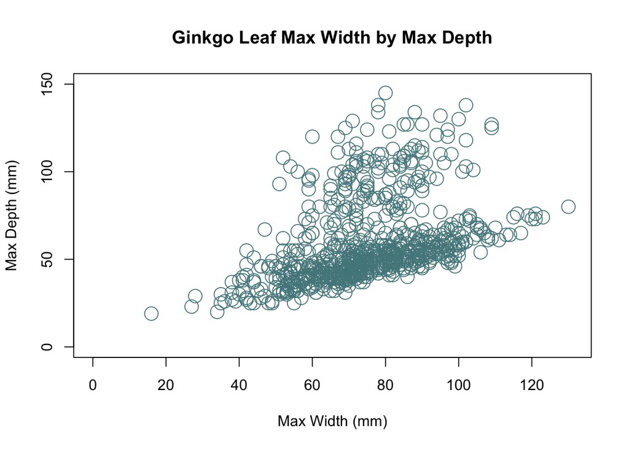

```r
# col = color
# pch = symbol
# cex = size
plot(ginkgo$max_width, ginkgo$max_depth, col = "cadetblue4",
     pch = 1, cex = 2, main = "Ginkgo Leaf Max Width by Max Depth", xlab = "Max Width (mm)", ylab = "Max Depth (mm)", xlim = c(0,131), ylim = c(0,150))
```

### Histograms

Histograms graph data as bar charts based on the frequency of data. They are good at evaluating distribution. Use **par()** to put all histograms in one figure.

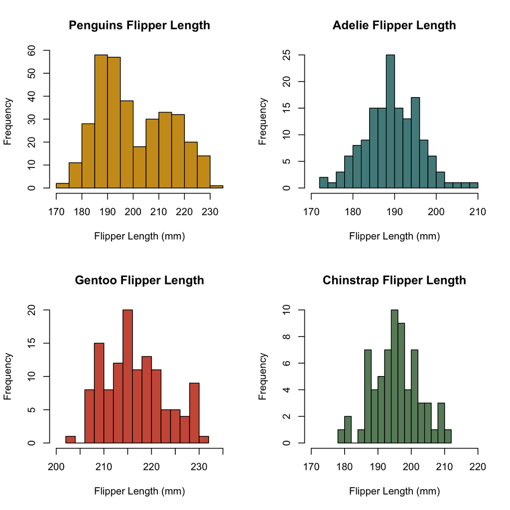

```r
par(mfrow=c(2,2))
hist(penguins$flipper_length_mm,
     main = "Penguins Flipper Length",
     xlab = "Flipper Length (mm)", col = "goldenrod3",
     breaks = 15, xlim = c(170,235))
hist(Adelie$flipper_length_mm,
     main = "Adelie Flipper Length",
     xlab = "Flipper Length (mm)", col = "darkslategray4",
     breaks = 15, xlim = c(170,210))
hist(Gentoo$flipper_length_mm,
     main = "Gentoo Flipper Length",
     xlab = "Flipper Length (mm)", col = "coral3",
     breaks = 15, xlim = c(200,235))
hist(Chinstrap$flipper_length_mm,
     main = "Chinstrap Flipper Length",
     xlab = "Flipper Length (mm)", col = "darkseagreen4",
     breaks = 15, xlim = c(170,220))
```

### Boxplots

Boxplots are good for looking at the spread of the data as well as the distribution. They are also helpful when comparing variables of the data set.

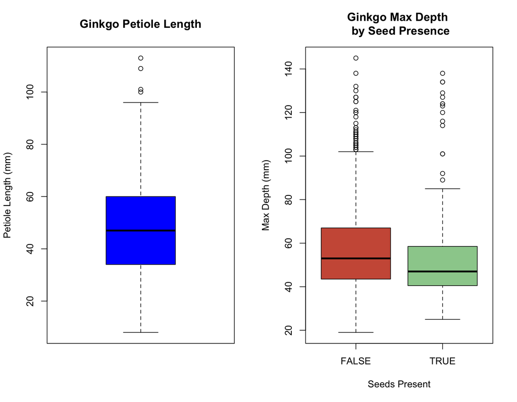

```r
par(mfrow=c(1,2))
# Simple boxplot
boxplot(ginkgo$petiole_length, main = "Ginkgo Petiole Length",
        ylab = "Petiole Length (mm)", col = "blue")

# Conditional boxplot
boxplot(max_depth ~ seeds_present, data = ginkgo,
        main = "Ginkgo Max Depth \n by Seed Presence", xlab = "Seeds Present",
        ylab = "Max Depth (mm)", col = c("coral3", "darkseagreen3"))
```

## Disctribution Functions

- The Normal Distribution: Density, distribution function, quantile function and random generation for the normal distribution with mean equal to mean and standard deviation equal to sd.
- The Binomial Distribution: Density, distribution function, quantile function and random generation for the binomial distribution with parameters size and prob. This is conventionally interpreted as the number of ‘successes’ in size trials.
- Some of these examples came from **tutorialspoint.com**.

### Probability Density: dnorm()

Using **dnorm()** gives height of the probability distribution at each point for a given mean and standard deviation. dnorm(x, mean = 0, sd = 1, log = FALSE). x = a vector of **numbers**.

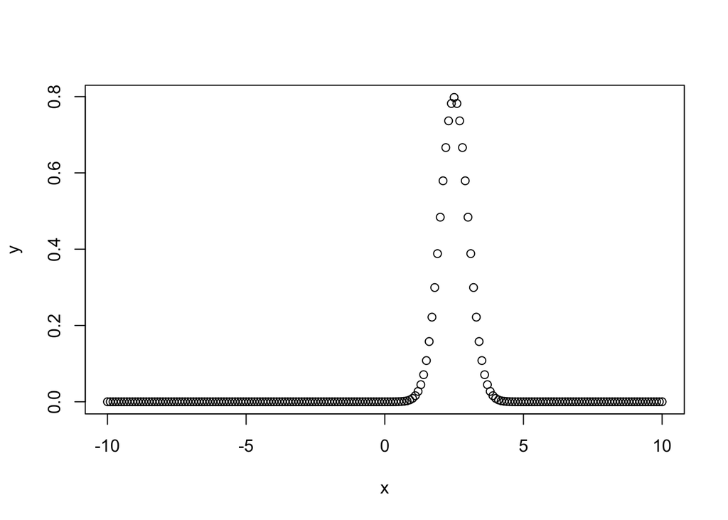

```r
# Create a sequence of numbers between -10 and 10 incrementing by 0.1.
x <- seq(-10, 10, by = .1)

# Choose the mean as 2.5 and standard deviation as 0.5.
y <- dnorm(x, mean = 2.5, sd = 0.5)
plot(x,y)
```

```r
# Finding the a single probability
dnorm(0.5, mean = 2.5, sd = 0.5)
```

```
## [1] 0.0002676605
```

### Cumulative Distribution Function: pnorm()

Using **pnorm()** gives the probability of a normally distributed random number to be less that the value of a given number. pnorm(q, mean = 0, sd = 1, lower.tail = TRUE, log.p = FALSE). q = a vector of **numbers**

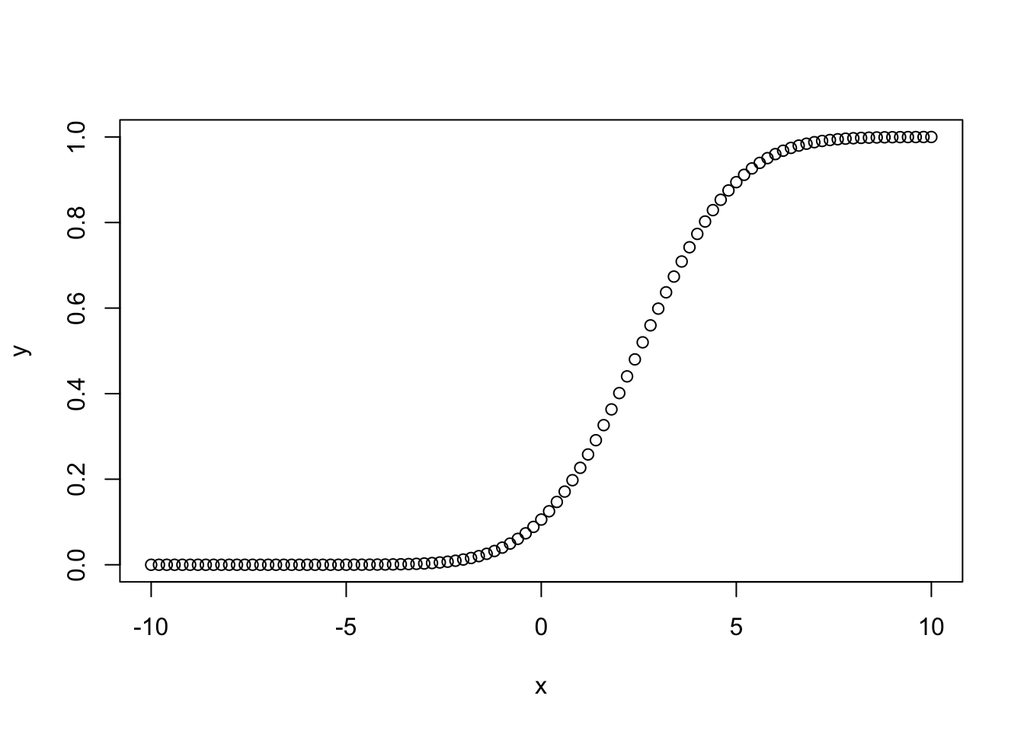

```r
# Create a sequence of numbers between -10 and 10 incrementing by 0.2.
x <- seq(-10,10,by = .2)

# Choose the mean as 2.5 and standard deviation as 2.
y <- pnorm(x, mean = 2.5, sd = 2)
plot(x,y)
```

```r
# Finding the a single probability
pnorm(3, mean = 2.5, sd = 2)
```

```
## [1] 0.5987063
```